# Principal Component Analysis (PCA)

# Standardizing the Data

### Step 2: Z-score Transformation

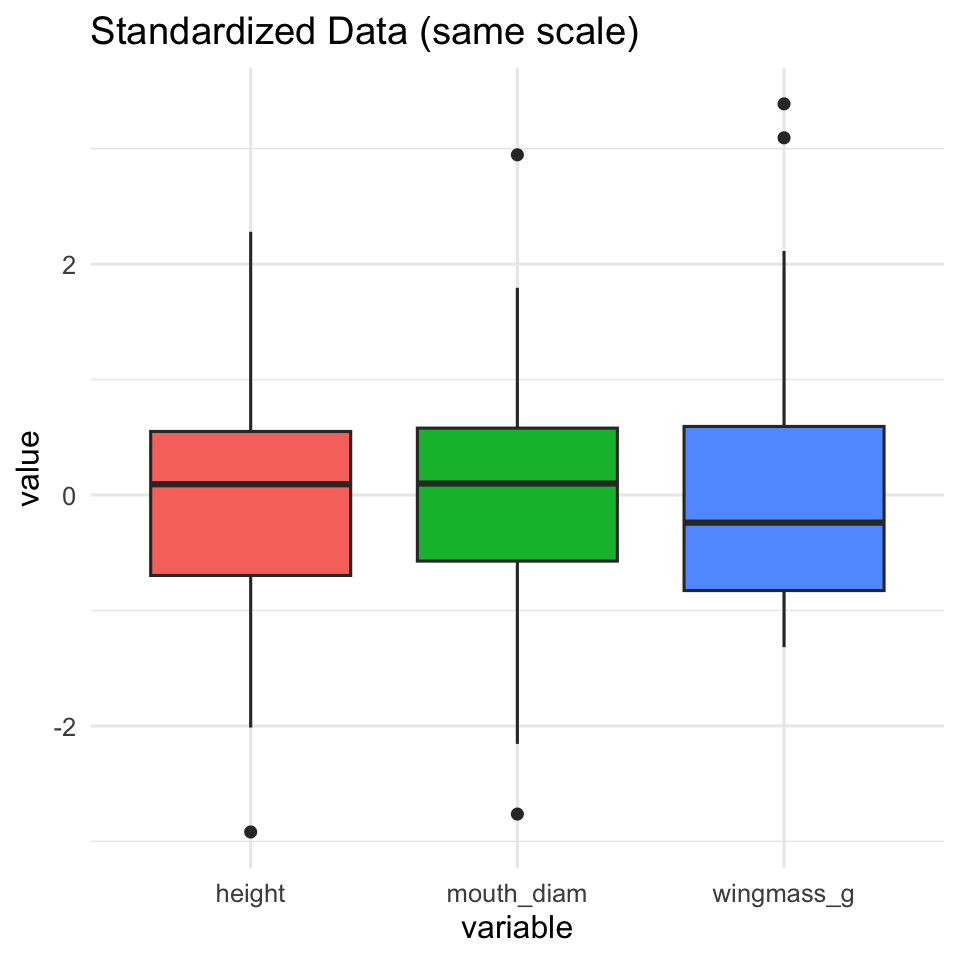

### Visualizing Standardized Data

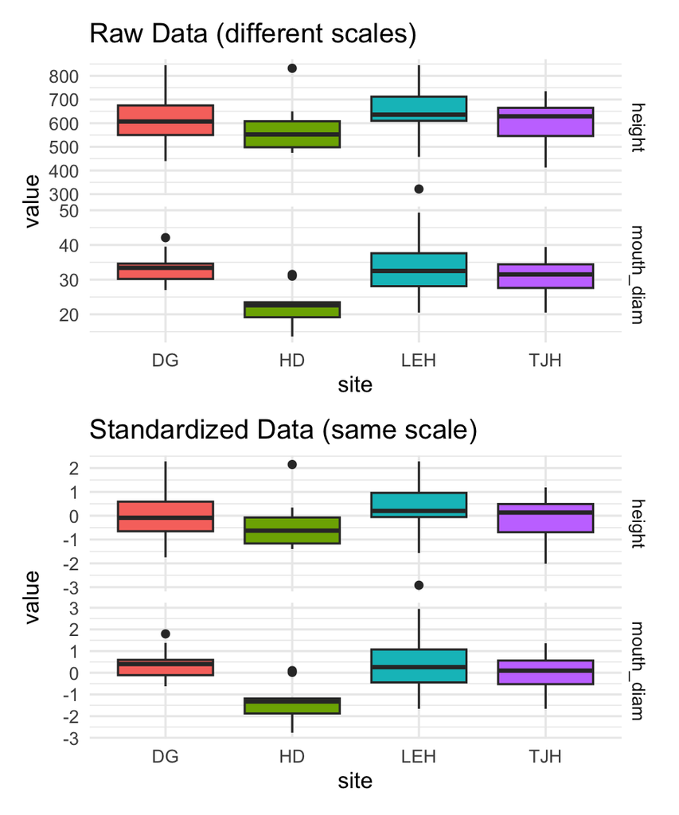

# Understanding Correlations

### Why Correlations Matter for PCA

- PCA works best when variables are **correlated**:
  - If variables are uncorrelated → PCA provides no benefit
  - If variables are highly correlated → PCA can reduce dimensions effectively
- **In data**, expect correlations because:
  - Larger plants have larger measurements overall
  - Wing dimensions likely correlate with each other
  - Mass measurements correlate with size measurements
- **The correlation matrix** shows relationships between all pairs of variables.
- Strong correlations (positive or negative) suggest PCA will be useful!

**Strong positive correlations** (dark blue) suggest variables measure similar aspects of plant size/shape.

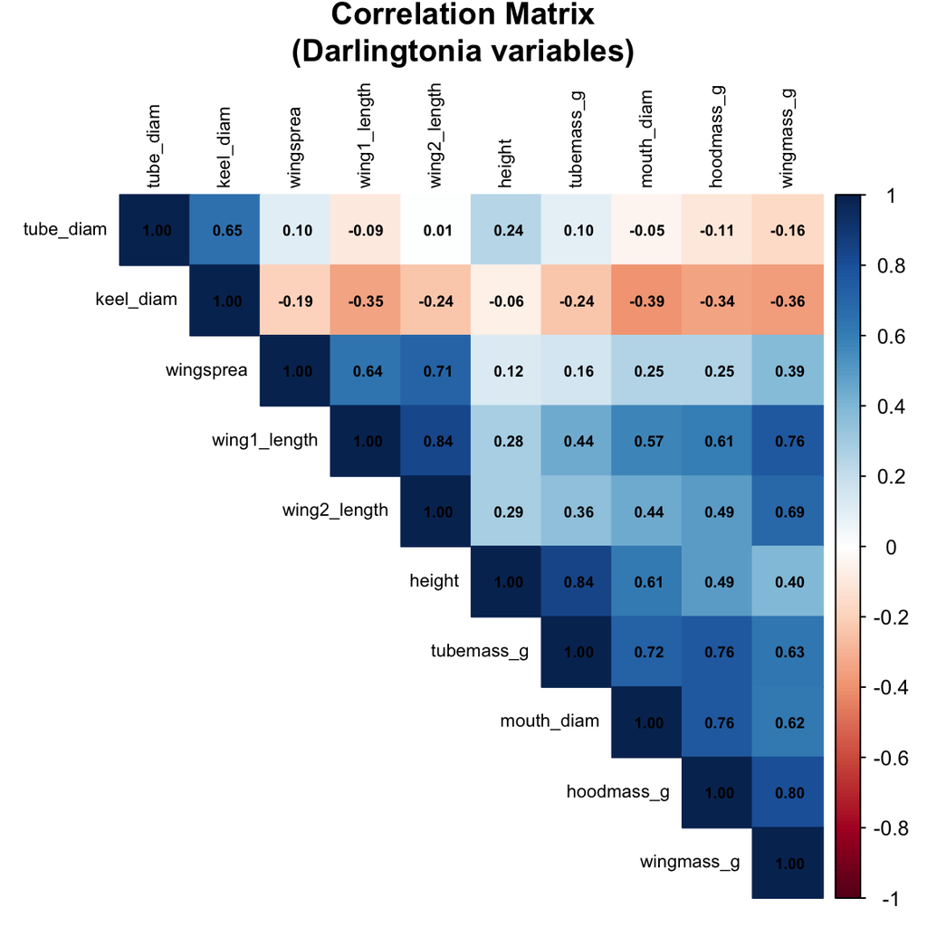

# Correlation Matrix Details

### Examining Variable Relationships

```
##              height mouth_diam tube_diam keel_diam wing1_length wing2_length
## height         1.00       0.61      0.24     -0.06         0.28         0.29
## mouth_diam     0.61       1.00     -0.05     -0.39         0.57         0.44
## tube_diam      0.24      -0.05      1.00      0.65        -0.09         0.01
## keel_diam     -0.06      -0.39      0.65      1.00        -0.35        -0.24
## wing1_length   0.28       0.57     -0.09     -0.35         1.00         0.84
## wing2_length   0.29       0.44      0.01     -0.24         0.84         1.00
## wingsprea      0.12       0.25      0.10     -0.19         0.64         0.71
## hoodmass_g     0.49       0.76     -0.11     -0.34         0.61         0.49
## tubemass_g     0.84       0.72      0.10     -0.24         0.44         0.36
## wingmass_g     0.40       0.62     -0.16     -0.36         0.76         0.69
##              wingsprea hoodmass_g tubemass_g wingmass_g
## height            0.12       0.49       0.84       0.40
## mouth_diam        0.25       0.76       0.72       0.62
## tube_diam         0.10      -0.11       0.10      -0.16
## keel_diam        -0.19      -0.34      -0.24      -0.36
## wing1_length      0.64       0.61       0.44       0.76
## wing2_length      0.71       0.49       0.36       0.69
## wingsprea         1.00       0.25       0.16       0.39
## hoodmass_g        0.25       1.00       0.76       0.80
## tubemass_g        0.16       0.76       1.00       0.63
## wingmass_g        0.39       0.80       0.63       1.00
```